# About Roel

Roel M. Hogervorst

You are now on rmhogervorst.nl

Hi I’m Roel Hogervorst ( Roel M. Hogervorst MSc. )

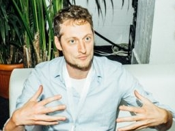

on most platforms (github, gitlab, etc.) I go by RMHogervorst.

Currently I’m a Data Scientist / Data Engineer at Ordina This entry was last updated at 2022-11-03.

I really like R, programming and data engineering.

But R is not the only language in the world. I work with Python and SQL too. I try to update this page, but if you want to see what I’m currently working on, you should check out my github profile (I develop almost everything in the open) on https:://github.com/rmhogervorst .

I often find myself building tools for personal use that are useful for others as well. My current interests are: R, open source, open science and reproducible research. I dabble in text analyses, prediction and automation.

You can find my [blogposts here](https://blog.rmhogervorst.nl). R-specific posts (most of my blogposts) are also syndicated to [r-bloggers](https://www.r-bloggers.com/author/roel-m-hogervorst/) and I syndicate posts to [dev.to](https://dev.to/rmhogervorst) too. When I have half-finished work, that nevertheless needs a place to live, I post it to my secondary blog [notes.rmhogervorst.nl](https://notes.rmhogervorst.nl/)

You can find me on many social media platforms:

- I’m on twitter as [@RoelMHogervorst](https://twitter.com/RoelMHogervorst).
- I’m on [linkedIn](https://www.linkedin.com/in/rmhogervorst) too
- I started a [Mastodon](https://mastodon.world/@rmhogervorst) account too.
- My keybase is here https://keybase.io/rmhogervorst/ though I think most people left keybase

You can find a lot of my work on * [github](https://github.com/RMHogervorst) * [gitlab](https://gitlab.com/rmhogervorst) * [bitbucket](https://bitbucket.org/RMHogervorst/) (not a lot there).

Contact me for issues on [github](https://github.com/RMHogervorst). Or if you really must, you can email me at hogervorst (dot) rm (at) gmail.com